# Beer Ratings Analysis

Matt Dube

12/7/2018

load libraries

```r
library(dplyr)
library(ggplot2)
library(tidyr)
library(here)
library(corrplot)
library(Hmisc)
```

load data

```r
beer <- read.csv(here("00_Data/raw/","beer_reviews.csv"), stringsAsFactors = FALSE)
```

Look at structure of data

```r
dim(beer)
```

```
[1] 1586614      13
```

```r
glimpse(beer)
```

```
Observations: 1,586,614
Variables: 13
$ brewery_id         <dbl> 10325, 10325, 10325, 10325, 1075, 1075, 1075, 1075, 1075, 1075, 163, 1075...
$ brewery_name       <chr> "Vecchio Birraio", "Vecchio Birraio", "Vecchio Birraio", "Vecchio Birraio...
$ review_time        <dbl> 1234817823, 1235915097, 1235916604, 1234725145, 1293735206, 1325524659, 1...
$ review_overall     <dbl> 1.5, 3.0, 3.0, 3.0, 4.0, 3.0, 3.5, 3.0, 4.0, 4.5, 3.0, 5.0, 4.0, 4.0, 3.5...
$ review_aroma       <dbl> 2.0, 2.5, 2.5, 3.0, 4.5, 3.5, 3.5, 2.5, 3.0, 3.5, 2.0, 5.0, 4.0, 4.5, 4.0...
$ review_appearance  <dbl> 2.5, 3.0, 3.0, 3.5, 4.0, 3.5, 3.5, 3.5, 3.5, 5.0, 3.0, 4.0, 4.0, 3.0, 3.0...
$ review_profilename <chr> "stcules", "stcules", "stcules", "stcules", "johnmichaelsen", "oline73", ...
$ beer_style         <chr> "Hefeweizen", "English Strong Ale", "Foreign / Export Stout", "German Pil...
$ review_palate      <dbl> 1.5, 3.0, 3.0, 2.5, 4.0, 3.0, 4.0, 2.0, 3.5, 4.0, 2.5, 4.0, 3.5, 2.5, 3.0...
$ review_taste       <dbl> 1.5, 3.0, 3.0, 3.0, 4.5, 3.5, 4.0, 3.5, 4.0, 4.0, 2.5, 4.0, 4.0, 3.0, 4.0...
$ beer_name          <chr> "Sausa Weizen", "Red Moon", "Black Horse Black Beer", "Sausa Pils", "Caul...
$ beer_abv           <dbl> 5.0, 6.2, 6.5, 5.0, 7.7, 4.7, 4.7, 4.7, 4.7, 4.7, 3.5, 4.7, 4.7, 4.7, 4.7...
$ beer_beerid        <dbl> 47986, 48213, 48215, 47969, 64883, 52159, 52159, 52159, 52159, 52159, 436...
```

```r
summary(beer)
```

```
   brewery_id    brewery_name        review_time        review_overall   review_aroma
 Min.   :    1   Length:1586614     Min.   :8.407e+08   Min.   :0.000   Min.   :1.000
 1st Qu.:  143   Class :character   1st Qu.:1.173e+09   1st Qu.:3.500   1st Qu.:3.500
 Median :  429   Mode  :character   Median :1.239e+09   Median :4.000   Median :4.000
 Mean   : 3130                      Mean   :1.224e+09   Mean   :3.816   Mean   :3.736
 3rd Qu.: 2372                      3rd Qu.:1.289e+09   3rd Qu.:4.500   3rd Qu.:4.000
 Max.   :28003                      Max.   :1.326e+09   Max.   :5.000   Max.   :5.000

 review_appearance review_profilename  beer_style        review_palate    review_taste
 Min.   :0.000     Length:1586614     Length:1586614     Min.   :1.000   Min.   :1.000
 1st Qu.:3.500     Class :character   Class :character   1st Qu.:3.500   1st Qu.:3.500
 Median :4.000     Mode  :character   Mode  :character   Median :4.000   Median :4.000
 Mean   :3.842                                           Mean   :3.744   Mean   :3.793
 3rd Qu.:4.000                                           3rd Qu.:4.000   3rd Qu.:4.500
 Max.   :5.000                                           Max.   :5.000   Max.   :5.000

  beer_name            beer_abv      beer_beerid
 Length:1586614     Min.   : 0.01   Min.   :    3
 Class :character   1st Qu.: 5.20   1st Qu.: 1717
 Mode  :character   Median : 6.50   Median :13906
                    Mean   : 7.04   Mean   :21713
                    3rd Qu.: 8.50   3rd Qu.:39441
                    Max.   :57.70   Max.   :77317
                    NA's   :67785
```

It looks like only beer_abv has missing values. I’ll check again with less output to make sure.

```r
sapply(beer, function(x) sum(is.na(x)))
```

```
        brewery_id       brewery_name        review_time     review_overall       review_aroma
                 0                 15                  0                  0                  0
 review_appearance review_profilename         beer_style      review_palate       review_taste
                 0                348                  0                  0                  0
         beer_name           beer_abv        beer_beerid
                 0              67785                  0
```

```r
67785 / nrow(beer) * 100
```

```
[1] 4.272306
```

4.27% of reviews have missing data.

#### Question 1: Which brewery produces the strongest beers by ABV%?

There’s a 3-step process to answer this question: * get distinct list of beers * group by brewery * find the average ABV% for all the beers by brewery

```r
beer %>%
    distinct(brewery_name, brewery_id, beer_name, beer_beerid, beer_abv) %>%
    group_by(brewery_name) %>%
    summarise(mean_abv = mean(beer_abv)) %>%
    arrange(desc(mean_abv)) %>%
    head(5)
```

| brewery_name | mean_abv |
| --- | --- |
| Schorschbräu | 24.69000 |
| Shoes Brewery | 15.20000 |
| Rascal Creek Brewing Co. | 13.00000 |
| Monks Porter House | 12.46667 |
| Rinkuki&#371; Aluas Darykla | 12.00000 |

The brewery that produces the strongest beers by ABV% is **SchorschbrÃ¤u** with a mean abv of **24.69**.

#### Question 2: If you had to pick 3 beers to recommend using only this data, which would you pick?

First set is to add a review_count column, which is the total number of times a unique beer was reviewed.

```r
beer_processed <-
    beer %>%
    group_by(beer_name, beer_beerid) %>%
    mutate(review_count = n())
```

Next, I’m choosing an arbitrary number of minimum reviews to base my selection on. In this case, I think that a minimum of 20 reviews for a beer is needed before it can be considered for the overall recommendation.

The steps to choose the 3 beers are:

1. Filter on beers with at least 20 reviews.
2. Group_By Beer Name, Beer ID, and Brewery.
3. Find the mean overall rating (review_overall) for those beers.
4. Arrange the results in descending order by mean_over_all rating.

```r
beer_processed %>%
  filter(review_count >= 20) %>%
  group_by(beer_name, beer_beerid, brewery_name) %>%
  summarise(mean_overall_rating = mean(review_overall, na.rm=TRUE), n()) %>%
  select(mean_overall_rating, beer_name, everything()) %>%
  arrange(desc(mean_overall_rating, n)) %>%
  head(3)
```

| mean_overall_rating | beer_name | beer_beerid | brewery_name | n() |
| --- | --- | --- | --- | --- |
| 4.848485 | Rare D.O.S. | 63649 | Peg's Cantina & Brewpub / Cycle Brewing | 33 |
| 4.820513 | Dirty Horse | 44910 | De Struise Brouwers | 39 |
| 4.768293 | Southampton Berliner Weisse | 8626 | Southampton Publick House | 41 |

The 3 beers I would recommend are

- **Rare D.O.S.** from Peg’s Cantina & Brewpub / Cycle Brewing
- **Dirty Horse** from De Struise Brouwers
- **Southampton Berliner Weisse** from Southampton Publick House

**Note** - this answer will change based on the filter of number of beer reviews.

#### Question 3: Which of the factors (aroma, taste, appearance, palate) are most important in determining the overall quality of a beer?

My initial thought to answer question 3 was to build a model, then look at variable importance. But while that would give an answer, a much easier way to answer this is to look at the correlation of the 4 features with the overall rating, which I interpret to be the overall quality of the beer.

First step, check the distribution of aroma, taste, appearance, and palate.

A fuction to plot a list of variables:

```r
plotHistograms <- function(varList, inputData, numCols=2) {
    gather(data=inputData, varList, key = "var", value = "value") %>%
        ggplot(aes(x=value)) +
        geom_histogram(fill="#2b8cbe") +
        facet_wrap(~ var, scales = "free", ncol = numCols) +
        theme(legend.position = "none")
}
```

Call the function with our list:

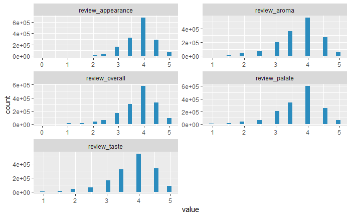

```r
num_list <- c("review_overall", "review_aroma", "review_taste", "review_appearance", "review_palate")
plotHistograms(num_list, beer)
```

All five variables distributions are basically the same, and close to normal. We can use Pearson’s correlation to examine the strength of their relationships. We can further check the relationship using Spearman’s Rank Correlation, which doesn’t make assumptions about the distribution.

```r
beer_corr_full_pe <-
    beer %>%
    dplyr::select(review_overall, review_aroma, review_taste, review_appearance, review_palate) %>%
    cor(method = "pearson")
beer_corr_full_sp <-
    beer %>%
    dplyr::select(review_overall, review_aroma, review_taste, review_appearance, review_palate) %>%
    cor(method = "spearman")
```

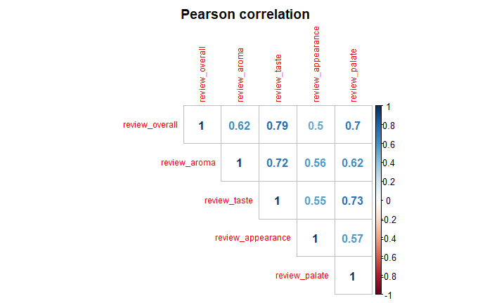

```r
corrplot(beer_corr_full_pe, method="number", type = "upper",tl.cex = 0.75,
         mar=c(0,0,2,0), title = "Pearson correlation")
```

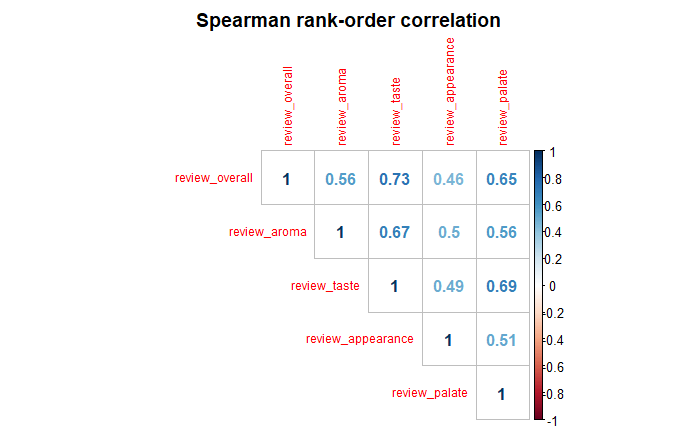

```r
corrplot(beer_corr_full_sp, method="number", type = "upper",tl.cex = 0.75,
         mar=c(0,0,2,0), title = "Spearman rank-order correlation")
```

Both Pearson and Spearman identify **review_taste** as the most important variable in determining the **review_overall** score.

#### Question 4: Generate 10,000 random numbers (i.e. sample) from a binomial distribution with p = 0.5 and N=20. Do not use any libraries or packages except basic math library functions and a random number generator (such as runif in R or random.random in python).

Plot the histogram of the data.

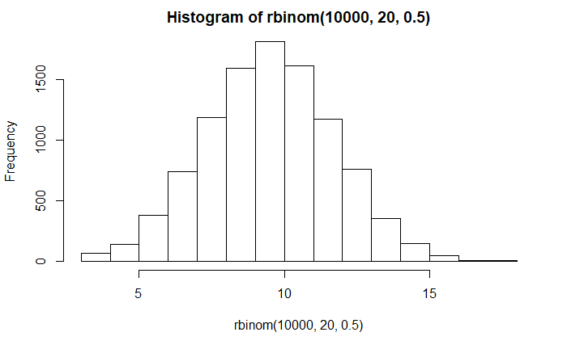

```r
hist(rbinom(10000, 20, 0.5))
```